# R Notebook

```r
library(tidyverse)
library(janitor)
library(lubridate)
```

```r
library(CodeClanData)

revenue <- qb_revenue_breakdown %>%
    clean_names()
monthly_sales <- qb_monthly_sales %>%
      clean_names()
competitors <- qb_competitors %>%
      clean_names()
device_data <- qb_device_data %>%
      clean_names()
```

```r
company_colours <- c("#E89FE9", "#50434F", "#B6A7B5", "#F9A472", "#BD7040")
```

# Part 1

## Question 1.

Take the data in the dataset qb_revenue_breakdown and make a stacked bar chart showing the sources of revenue across the two years in the dataset.

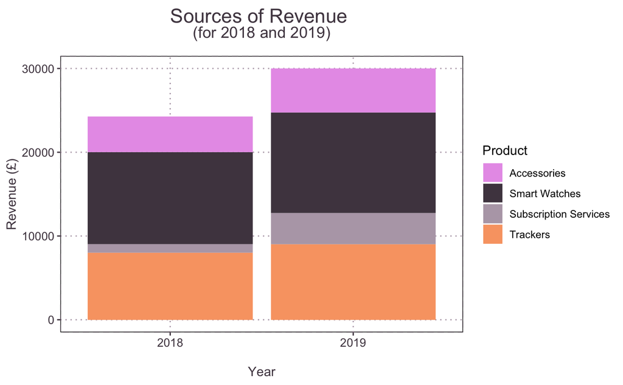

```r
ggplot(revenue) +
  geom_col(aes(x = year, y = revenue,
           fill = product)) +
  labs(
    x = "\nYear",
    y = "Revenue (£)",
    title = "Sources of Revenue ",
    subtitle = "(for 2018 and 2019)\n",
    fill = "Product"
  ) +
  unified_theme() +
  scale_fill_manual(values = company_colours)
```

## Question 2.

Make a line chart showing monthly sales of the “flagship product” - the ‘KwikBit Unit 1’ - over the last year. This data is inside qb_monthly_sales, but you will need to use filter() or subset() (base R).

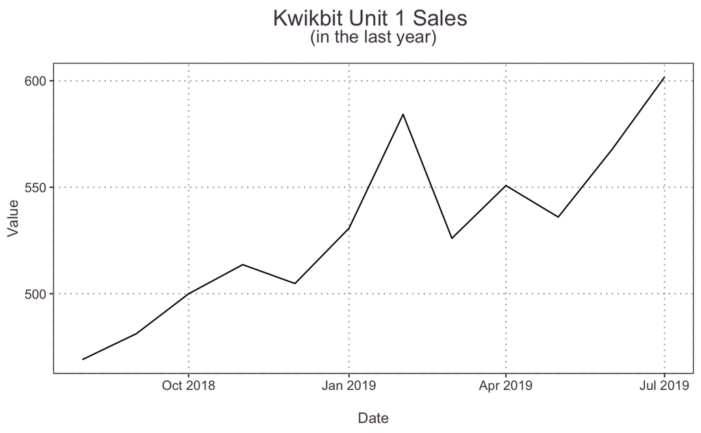

```r
monthly_sales %>%
  filter(cashflow == "Kwikbit Unit 1 Sales") %>%
ggplot(aes(x = date,
           y = amount)) +
  geom_line() +
  labs(
    x = "\nDate",
    y = "Value",
    title = "Kwikbit Unit 1 Sales ",
    subtitle = "(in the last year)\n"
  ) +
  unified_theme()
```

## Question 3.

Make a line chart showing monthly revenue and costs over the last year. This data is also in qb_monthly_sales.

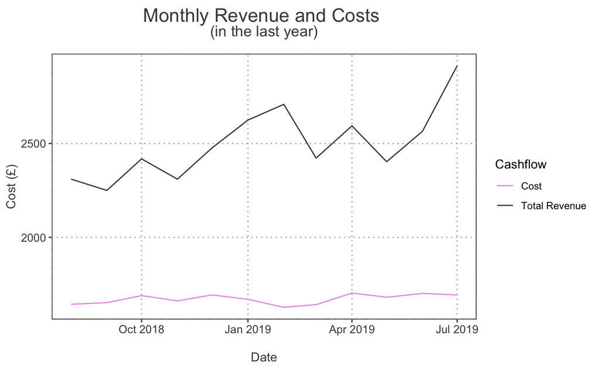

```r
monthly_sales %>%
  filter(cashflow != "Kwikbit Unit 1 Sales") %>%
  ggplot(aes(x = date,
           y = amount,
           colour = cashflow)) +
  geom_line(linetype = 1) +
  labs(
    x = "\nDate",
    y = "Cost (£)",
    title = "Monthly Revenue and Costs ",
    subtitle = "(in the last year)\n",
    colour = "Cashflow"
  ) +
  unified_theme()  +
  scale_colour_manual(values = company_colours)
```

## Question 4.

Show annual sales of personal fitness trackers over the last 5 years broken down by company as a ribbon plot (use geom_area). This data is in qb_competitors.

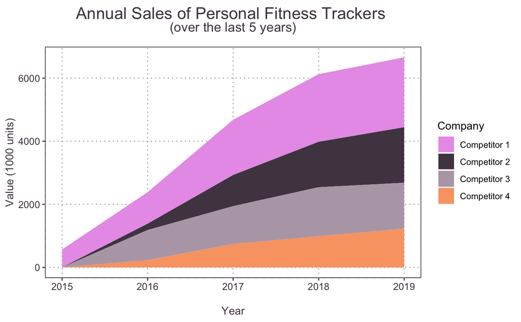

```r
competitors %>%
  mutate(revenue_thousands = revenue/1000) %>%
  ggplot(aes(x = year,
           y = revenue_thousands,
           fill = company)) +
  geom_area() +
  labs(
    x = "\nYear",
    y = "Value (1000 units)",
    title = "Annual Sales of Personal Fitness Trackers ",
    subtitle = "(over the last 5 years)\n",
    fill = "Company"
  )+
  unified_theme()  +
  scale_fill_manual(values = company_colours)
```

## Question 5.

Now show the sales from the four competitors as a line graph. Include an extra layer that shows the data points used to make the lines.

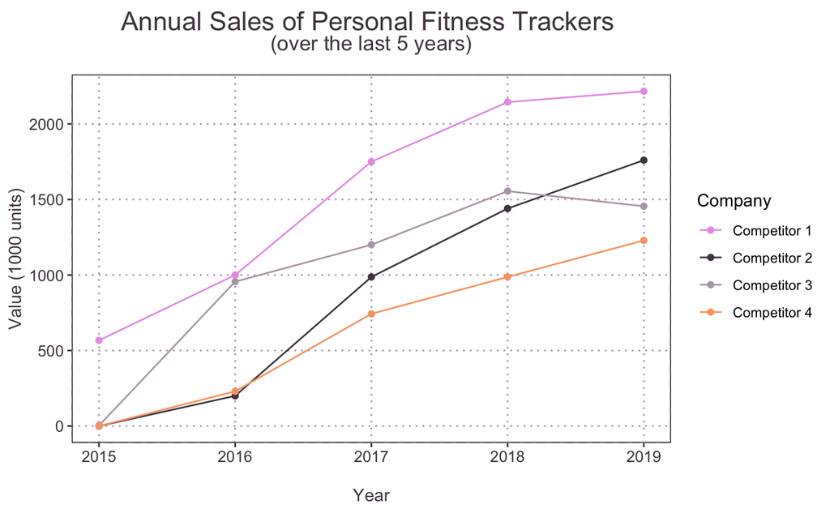

```r
competitors %>%
  mutate(revenue_thousands = revenue/1000) %>%
  ggplot(aes(x = year,
           y = revenue_thousands,
           colour = company)) +
  geom_line(aes (group = company)) +
  geom_point() +
  labs(
    x = "\nYear",
    y = "Value (1000 units)",
    title = "Annual Sales of Personal Fitness Trackers ",
    subtitle = "(over the last 5 years)\n",
    colour = "Company"
  ) +
  unified_theme()  +
  scale_colour_manual(values = company_colours)
```

## Question 6.

Now the company wants to compare the number of steps that their device counts vs. their competitors. Make a line graph of the number of steps throughout time, and use faceting to compare between companies and people. The data for this is in qb_device_data.

```r
#device_data <- device_data %>%
 # unite("time", hours:mins, sep = ":") %>%
  #mutate(time = as.POSIXct(time, format = "%H:%M"))
```

```r
# NOTE THIS IS NOT WORKING CORRECTLY
# ggplot(device_data)
#   (aes(x = time,y = counts, colour = id)) +
#   geom_line() +
#   scale_x_datetime(labels = time_format(format = "%H:%M")) +
#   facet_wrap(id ~ device) +
#   labs(
#     x = "\nTime",
#     y = "Count of Steps",
#     title = "Step Count",
#     subtitle = "(for Competitors and qikbit1)\n",
#     colour = "Company"
#   )
#   unified_theme()  +
#   scale_colour_manual(values = company_colours)
```

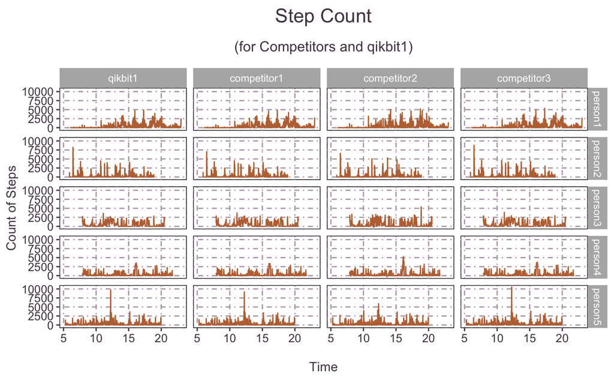

```r
# USING HOMEWORK ANSWERS
device_data <-
mutate(device_data, decimal_hour = hours + (mins/60))

ggplot(device_data) +
  aes(x = decimal_hour, y = counts) +
  geom_line(colour = "#BD7040") +
  facet_grid(id ~ device) +
   labs(
     x = "\nTime",
     y = "Count of Steps",
     title = "Step Count",
     subtitle = "\n(for Competitors and qikbit1)\n",
     colour = "Company"
   ) +
  unified_theme()
```

# Part 2

## **Question 1.**

Take the plots that you produced in part one and now polish them by:

1. Adding appropriate labels
2. Changing the scales and coordinates when appropriate.
3. Applying a unified theme, which is described below:
- Graphs should have white backgrounds, and use colour sparingly.
- There should be faint grid lines.
- Font sizes should be ~12pt although titles should be slightly larger and axis labels can be slightly smaller.
- All plots should use colours from the following company colour scheme.

```r
unified_theme <- function() {
  font <- "Georgia"   #assign font family up front

  theme_light() %+replace%    #replace elements we want to change

  theme(
    # add border
    panel.border = element_rect(colour = "#50434F", fill = NA, linetype = 2),

    # colour background
    panel.background = element_rect(fill = "white"),

    # modify grid
    panel.grid.major = element_line(colour = "#B6A7B5",
                                      linetype = 4, size = 0.5),
    panel.grid.minor = element_blank(),

    # modify text, axis and colour
    axis.text = element_text(colour = "#50434F", size = rel(0.9)),
    axis.title = element_text(colour = "#50434F"),
    axis.ticks = element_line(colour = "#50434F"),

    # modify titles and subtitles
    plot.title = element_text(colour = "#50434F",
                               size = rel(1.5)),
    plot.subtitle = element_text(colour = "#50434F",
                                  size = rel(1.1))
  )
}
```

```r
# Theme from answers
theme_qb <-
  theme(
    text = element_text(size = 12),
    title = element_text(size = 14),
    axis.text = element_text(size = 10),
    panel.background = element_rect(fill = "white"),
    panel.grid = element_line(colour = "grey90", linetype = "dashed")
  )
```

# **Part 3 - Extension**

**Question 1.**  
Try out different ways of plotting these three datasets. Which graphs do you think are particularly effective at showing QikBit’s success?